# Modelling infectious disease transmission potential as a function of human behaviour

Caroline E. Walters, Maria Bekker-Nielsen Dunbar, Dale Weston, Ian Hall

2024-12-05

# Background material

Mathematical modelling is an important public health tool for aiding the understanding of the spread of infectious diseases, and for quantifying the effects of behavioural interventions.

A mathematical model of fomite disease transmission via luggage trays at airport security screening in airport during an outbreak is used below. An intervention is placed in the setting with users of airport offered hand sanitiser gel before and after contact with trays. We then apply a theoretical behaviour on individuals in line with the extended parallel processing model (EPPM).

Firstly we load required packages (ggplot2) and define a function that simulates the interaction between the users and the trays. This uses the $\tau$-leap method for stochastic simulation and follows the modelling proposed in [Walters et al](https://www.medrxiv.org/content/10.1101/2021.07.16.21260521v1).

```r
library(ggplot2)
library(latex2exp)
library(gridExtra)

#####tau leap tray simulation
sis_tray_sim=function(dt=0.1,MaxTime=10000,N0=400,T0=0,probtrans=1/15,
                      people=20000, usebefore=0, useafter=0, prev=1/100,recrate=1,plt=T)
{
  # definitions
  t=dt*(0:MaxTime)
  TC=T0
  cases <- rbinom(length(t),prob=prev*dt, size=people)
  firstdeconfail <- rbinom(length(t),prob=1-usebefore, size=cases)
  trayspercustomer <- 2

  # loop over time
  for (i in 2:(MaxTime+1))
  {
    R1=probtrans*firstdeconfail[i-1]*(1-TC[i-1]/N0)  #transmission rate
    R2=recrate*TC[i-1]*dt  # recovery rate

    dmc=rpois(1,R1)
    dmr=rpois(1,R2)

    if(dmc>N0-TC[i-1]) dmc=N0-TC[i-1]
    if(dmr>TC[i-1]) dmr=TC[i-1]

    TC[i]=TC[i-1]+dmc-dmr
  }
  alpha <- probtrans*TC/TraysperLane*trayspercustomer
 # DeltaP <- rbinom(n=length(TC),prob=1-prev, size=alpha)
  ss <- (1-usebefore)*probtrans*prev*people/((1-usebefore)*probtrans*prev*people+N0*recrate)

  if(plt==T){
    # plot stochastic result and deterministic steady state
    plot(TC/N0~t,type="l",ylim=c(0,3*ss),ylab="Proportion",xlab="Time (days)",
         main=paste("Prop. Contaminated Trays, ", round(ss,4), sep=''))
    abline(h=ss, col=2)
    abline(h=mean(TC)/N0/dt, col=3)
  }

  # curate output values
  seconddeconfail <- rbinom(length(t),prob=1-useafter, size=firstdeconfail)
  newcase <- rbinom(length(t),prob=(1-useafter)*(1-prev)*alpha*dt, size=people)
  reinfcase <- rbinom(length(t),prob=(1-useafter)*alpha, size=cases-firstdeconfail)

  output<- data.frame(time=t,TC=TC, cases=cases, deconbefore=firstdeconfail, alpha=alpha, #DeltaP=DeltaP,
                      caseinspite=seconddeconfail, newcasefromtray = newcase, reinfcase=reinfcase)

    output
}
```

# Spoiler

We find that changing model assumptions of human behaviour in line with the EPPM gives qualitatively different results on the optimal placement of hand sanitiser gels within an airport compared to the model with naive behavioural assumptions.

Specifically, that it is preferable to place hand sanitiser gels after luggage screening in most scenarios, however in situations where individuals perceive high threat and low efficacy this strategy may need to be reviewed.

# Worked Example

Following example in [Walters et al](https://www.medrxiv.org/content/10.1101/2021.07.16.21260521v1) we assume the following (illustrative of values used in real world airport)

- There are 40 trays per queue and 10 queues at luggage screening so that there are 400 trays in use each day .
- There are 20,000 passengers per day, so each tray is touched by 50 people ($c=50$)
- We assume each user touches 2 trays ($m=2$)
- We also allow the virus to remain viable on the tray surface for 1 day ($\delta = 1$)
- We assume transmission is equal from person to tray as from tray to person so set $\beta = \gamma$
- We assume prevalence is 1%.

Declare these parameter choices:

```r
Num_of_trays <- 400
Customersperday <- 20*10^3
Lanes <- 10
TraysperLane <- Num_of_trays/Lanes
trayspercustomer <- 2
contactrate <- Customersperday/Num_of_trays #(per tray)

prevalence <- 0.01
probtransmissionpercontact <- 1/15 # beta=gamma, same either direction
transmission <- probtransmissionpercontact*contactrate*prevalence

recov <- 1

probtraycontaminated <- transmission/(transmission+recov)
```

Having declared values we simulate and check steady state is reasonable proxy.

```r
delt <- 0.1
contamtray <- sis_tray_sim(dt=delt, N0=TraysperLane, probtrans=probtransmissionpercontact, people=Customersperday/Lanes, prev=prevalence, recrate=recov)
```

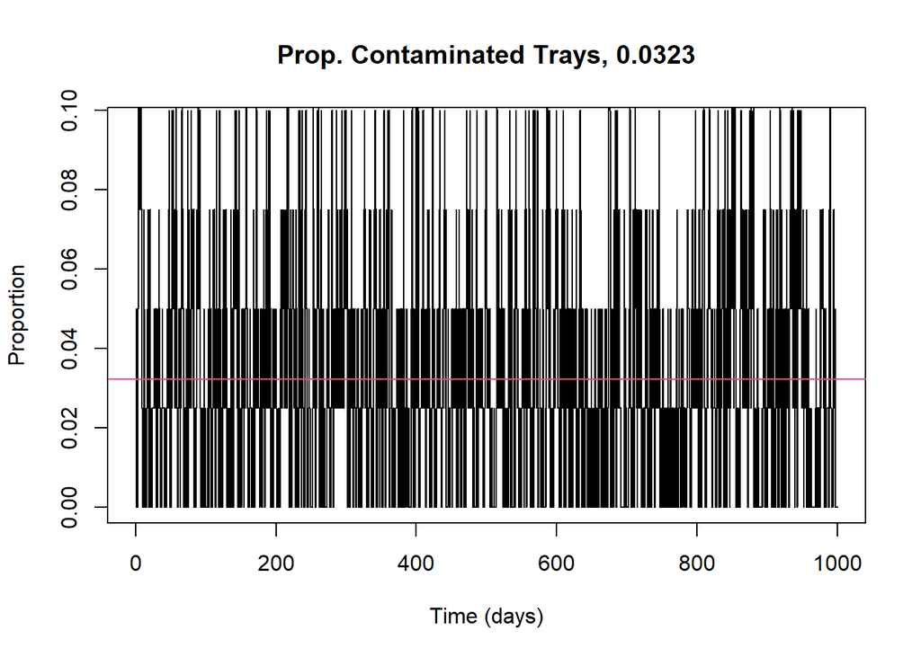

and after plotting check numerics

```r
c(mean(contamtray$TC)/TraysperLane, mean(contamtray$caseinspite)/delt/Customersperday*Lanes, mean(contamtray$newcasefromtray)/delt/Customersperday*Lanes, mean(contamtray$reinfcase)/delt/Customersperday*Lanes)
```

```
## [1] 0.032409259 0.009979002 0.004306569 0.000000000
```

```r
c(probtraycontaminated, prevalence, (1-prevalence)*trayspercustomer*probtransmissionpercontact*probtraycontaminated)
```

```
## [1] 0.032258065 0.010000000 0.004258065
```

## Introducing hand hygiene

Now simply assume 50% of users use sanitiser before and after.

```r
delt <- 0.1
use <- 0.5
contamtray <- sis_tray_sim(dt=delt, N0=TraysperLane, probtrans=probtransmissionpercontact, usebefore=use, useafter = use, people=Customersperday/Lanes, prev=prevalence, recrate=recov)
```

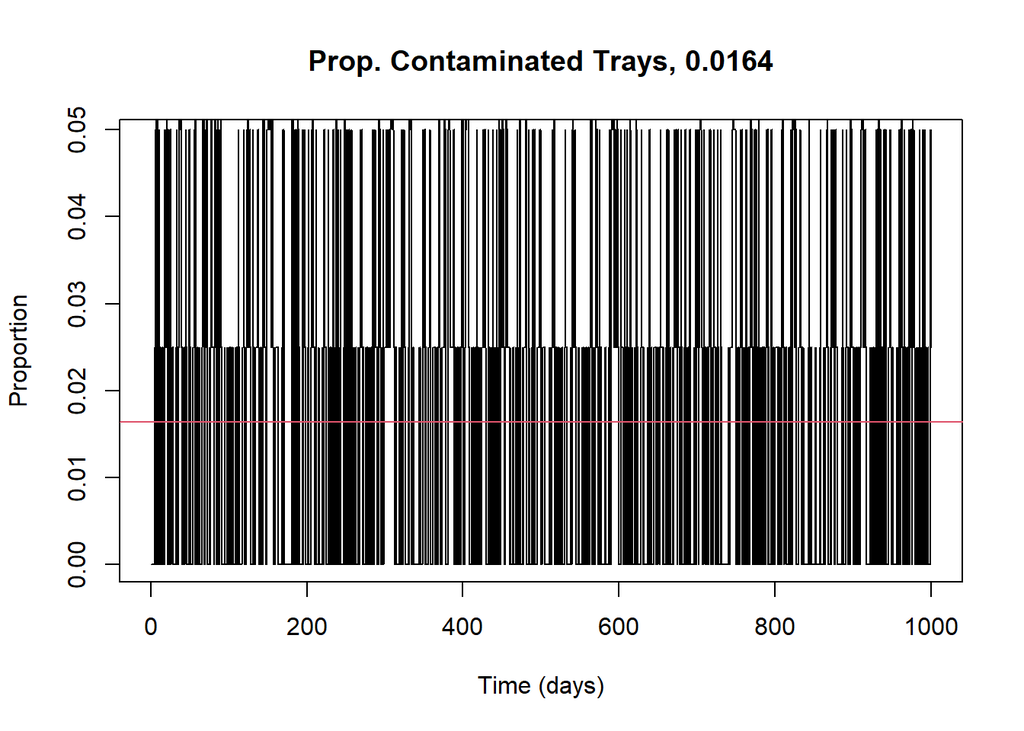

```r
c(mean(contamtray$TC)/TraysperLane, mean(contamtray$caseinspite)/delt/Customersperday*Lanes, mean(contamtray$newcasefromtray)/delt/Customersperday*Lanes, mean(contamtray$reinfcase)/delt/Customersperday*Lanes)
```

```
## [1] 0.0177207279 0.0025167483 0.0011698830 0.0000069993
```

```r
probtraycontaminated <- (1-use)*transmission/((1-use)*transmission+recov)

c(probtraycontaminated, (1-use)*(1-use)*prevalence, (1-use)*(1-prevalence)*trayspercustomer*probtransmissionpercontact*probtraycontaminated,(1-use)*(use*prevalence)*trayspercustomer*probtransmissionpercontact*probtraycontaminated)
```

```
## [1] 1.639344e-02 2.500000e-03 1.081967e-03 5.464481e-06
```

So use of sanitiser has an effect.

# Testing model with random hand hygiene choice at both locations (section 2 of [Walters et al](https://www.medrxiv.org/content/10.1101/2021.07.16.21260521v1))

We now simulate the model 1000 times with probability of an individual using the sanitiser randomly drawn before and after contact with trays.

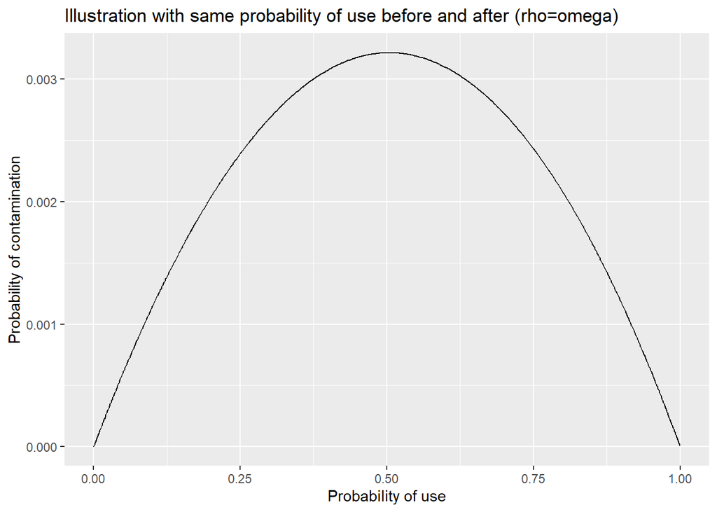

```r
nsim<- 1000

probtraycontaminated <- transmission/(transmission+recov)
Deltaprev <- (1-prevalence)*trayspercustomer*probtransmissionpercontact*probtraycontaminated

PC00 <- prevalence + Deltaprev
eta <- prevalence/PC00*(1-trayspercustomer*probtransmissionpercontact)

RandomUptake <- data.frame(useprior = runif(nsim, 0,1),
                            usepost = runif(nsim, 0,1))

RandomUptake$PCsame <- (1-RandomUptake$useprior)*(1-RandomUptake$useprior)*(1-probtraycontaminated*RandomUptake$useprior*eta)*PC00/(1-probtraycontaminated*RandomUptake$useprior)
# equation 4 but with rho=omega

RandomUptake$DeltaPCsame <- (1-RandomUptake$useprior)*(1-probtraycontaminated*RandomUptake$useprior*eta)/(1-probtraycontaminated*RandomUptake$useprior)-(1-RandomUptake$useprior)

ggplot(data=RandomUptake)+
  geom_line(mapping=aes(x=useprior, y=DeltaPCsame))+xlab('Probability of use')+ylab('Probability of contamination')+
  labs(title='Illustration with same probability of use before and after (rho=omega)')
```

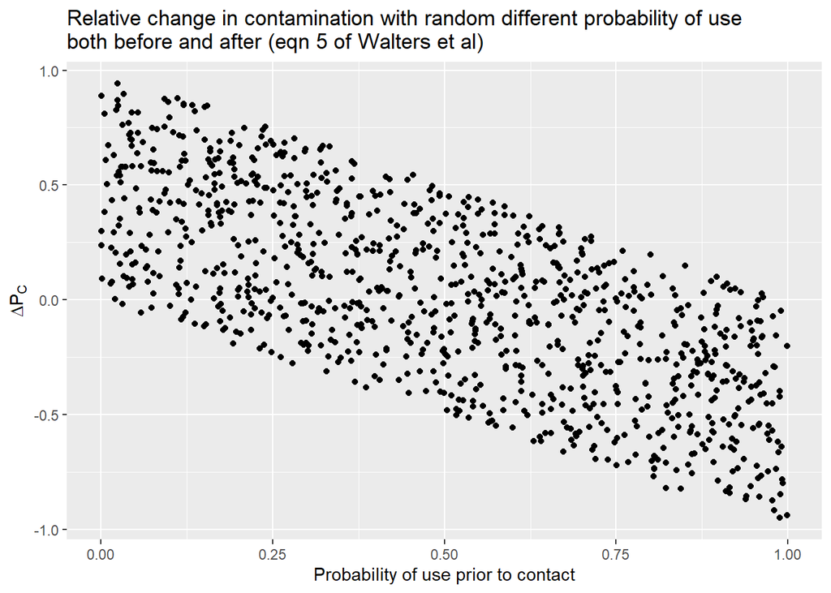

```r
# Now allow independent sample of uptake before and after (still random no EPPM)
RandomUptake$PC <- (1-RandomUptake$useprior)*(1-RandomUptake$usepost)*(1-probtraycontaminated*RandomUptake$useprior*eta)*PC00/(1-probtraycontaminated*RandomUptake$useprior)
# equation 4

RandomUptake$DeltaPC <- (1-RandomUptake$useprior)*(1-probtraycontaminated*RandomUptake$useprior*eta)/(1-probtraycontaminated*RandomUptake$useprior)-(1-RandomUptake$usepost)
# equation 5

RandomUptake$DeltaPCwq8 <- RandomUptake$usepost-RandomUptake$useprior+
  RandomUptake$useprior*probtraycontaminated*(1-eta)*(1-RandomUptake$useprior)/(1-probtraycontaminated*RandomUptake$useprior)
# equation 8

ggplot(data=RandomUptake)+
  geom_point(mapping=aes(x=useprior, y=DeltaPC))+xlab('Probability of use prior to contact')+ylab(TeX('$\\Delta P_C $'))+
  labs(title='Relative change in contamination with random different probability of use \nboth before and after (eqn 5 of Walters et al)')
```

```r
#plot((RandomUptake$useprior[which(RandomUptake$useprior>RandomUptake$usepost)]), RandomUptake$DeltaPC[which(RandomUptake$useprior>RandomUptake$usepost)])
#plot((RandomUptake$useprior[which(RandomUptake$useprior<RandomUptake$usepost)]), RandomUptake$DeltaPC[which(RandomUptake$useprior<RandomUptake$usepost)])
```

If $\delta P_C > 0$ then it is always optimal to place hand sanitiser gel after luggage screening to minimise the probability of contamination. This graph shows that this condition is met provided the probability of use is greater after contact is made ($\rho<\omega$). This is entirely predictable *a priori* but suggests that we now need to think about the factors that impact adherence before and after and how they might be modelled.

# Hand hygiene with chance of adherenece increasing with threat (Section 3.1 of [Walters et al](https://www.medrxiv.org/content/10.1101/2021.07.16.21260521v1))

Here we consider adherence increasing with threat and so define a efficacy of intervention and a perceived threat. Using the tray boosts the threat perception and so the probability of uptake of intervention is always greater after touching trays.

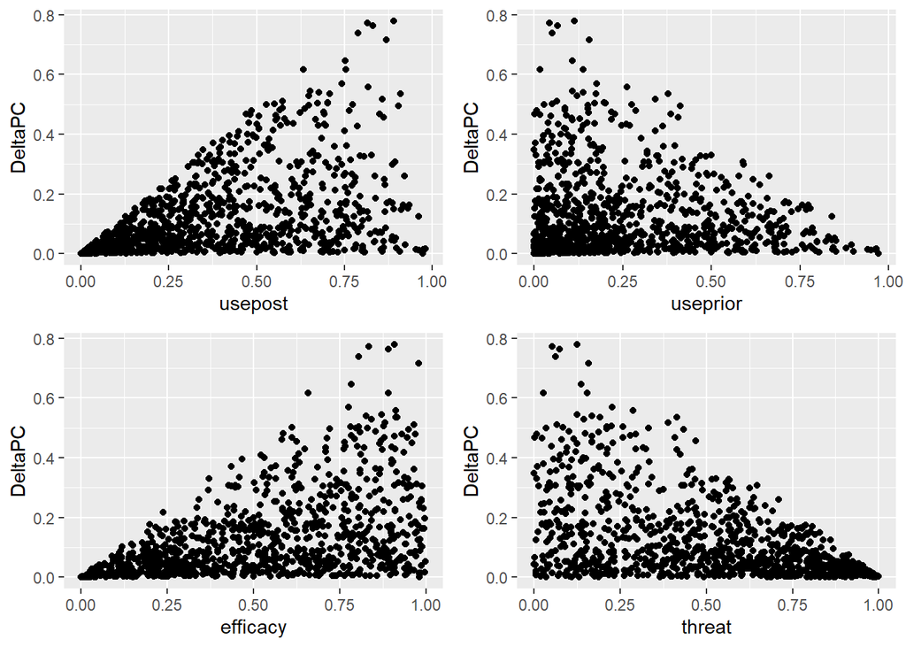

```r
nsim<- 1000

probtraycontaminated <- transmission/(transmission+recov)
Deltaprev <- (1-prevalence)*trayspercustomer*probtransmissionpercontact*probtraycontaminated

PC00 <- prevalence + Deltaprev
eta <- prevalence/PC00*(1-trayspercustomer*probtransmissionpercontact)

Uptake <- data.frame(threat = runif(nsim, 0,1),
                            efficacy = runif(nsim, 0,1))
Uptake$Inc <- runif(nsim,1, 1/Uptake$threat)

Uptake$useprior <- Uptake$efficacy*Uptake$threat
Uptake$usepost <- Uptake$Inc*Uptake$threat*Uptake$efficacy

Uptake$PC <- (1-Uptake$useprior)*(1-Uptake$usepost)*(1-probtraycontaminated*Uptake$useprior*eta)*PC00/(1-probtraycontaminated*Uptake$useprior)
# equation 4

Uptake$DeltaPC <- (1-Uptake$useprior)*(1-probtraycontaminated*Uptake$useprior*eta)/(1-probtraycontaminated*Uptake$useprior)-(1-Uptake$usepost)
# equation 5

Uptake$DeltaPCwq8 <- Uptake$usepost-Uptake$useprior+
  Uptake$useprior*probtraycontaminated*(1-eta)*(1-Uptake$useprior)/(1-probtraycontaminated*Uptake$useprior)
# equation 8

p1 <- ggplot(data=Uptake)+geom_point(mapping = aes(x=usepost, y=DeltaPC))
p2 <- ggplot(data=Uptake)+geom_point(mapping = aes(x=useprior, y=DeltaPC))
p3 <- ggplot(data=Uptake)+geom_point(mapping = aes(x=efficacy, y=DeltaPC))
p4 <- ggplot(data=Uptake)+geom_point(mapping = aes(x=threat, y=DeltaPC))

grid.arrange(p1, p2, p3, p4, ncol=2)
```

These 4 plots, all showing $\Delta P_C$ on $y$-axis, critically all values are positive and so it is always better to place sanitiser after trays than before trays if resources are tight and cannot be placed in both locations in this situation.

## Hand hygiene chance not increasing with threat. (Section 3.2 of [Walters et al](https://www.medrxiv.org/content/10.1101/2021.07.16.21260521v1))

Now we consider the situation that uptake is not increasing with threat and create a function to test sensitivity to prevalence

```r
DelPCcontour <- function(prevalence){
contactrate <- 50 #(per tray)
probtransmissionpercontact <- 1/15 # beta=gamma, same either direction
transmission <- probtransmissionpercontact*contactrate*prevalence

recov <- 1 # recovery rate
probtraycontaminated <- transmission/(transmission+recov)
trayspercustomer <- 2 # trays per customer
Deltaprev <- (1-prevalence)*trayspercustomer*probtransmissionpercontact*probtraycontaminated

PC00 <- prevalence + Deltaprev
eta <- prevalence/PC00*(1-trayspercustomer*probtransmissionpercontact)

# set up grid for threat and efficacy...
Uptake <- data.frame(threat = rep(c(0.001, seq(0.1,1,0.1)),11), #runif(nsim, 0,1),
                            efficacy = sort(rep(c(0.001,seq(0.1,1,0.1)),11))) #runif(nsim, 0,1))
# and change in perception after contact...
Uptake$Inc <- runif(length(Uptake$threat),1, 1/Uptake$threat)
# and calculate prior and post usage probability of deconamtination.
Uptake$useprior <- Uptake$efficacy*Uptake$threat*(Uptake$efficacy+1-Uptake$threat)
Uptake$usepost <- Uptake$Inc*Uptake$threat*Uptake$efficacy*(Uptake$efficacy+1-Uptake$Inc*Uptake$threat)

Uptake$PC <- (1-Uptake$useprior)*(1-Uptake$usepost)*(1-probtraycontaminated*Uptake$useprior*eta)*PC00/(1-probtraycontaminated*Uptake$useprior)
# equation 4

Uptake$DeltaPC <- (1-Uptake$useprior)*(1-probtraycontaminated*Uptake$useprior*eta)/(1-probtraycontaminated*Uptake$useprior)-(1-Uptake$usepost)
# equation 5

Uptake$DeltaPCwq8 <- Uptake$usepost-Uptake$useprior+
  Uptake$useprior*probtraycontaminated*(1-eta)*(1-Uptake$useprior)/(1-probtraycontaminated*Uptake$useprior)
# equation 8

ggplot(data=Uptake)+
     geom_contour_filled(mapping=aes(x=threat, y=efficacy, z=DeltaPC))+
     geom_abline(intercept=0, slope=1, color='white', lwd=2)
}
```

### Changing prevalence

This function works out equation 5 from [Walters et al](https://www.medrxiv.org/content/10.1101/2021.07.16.21260521v1) for given prevalence with the example disease and throughput parameters and specific choices of threat and efficacy. The value of $k$ is randomly sampled between $[1, 1/\tau]$ meaning the contour plots will change slightly each time the code is run.

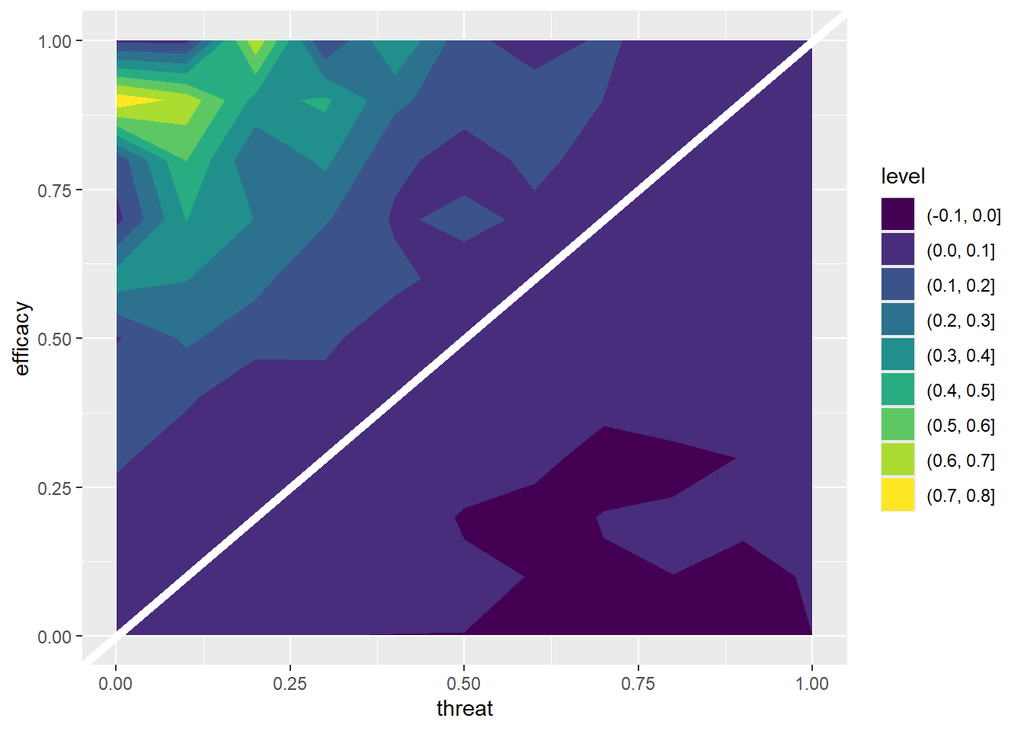

```r
DelPCcontour(0.9)
```

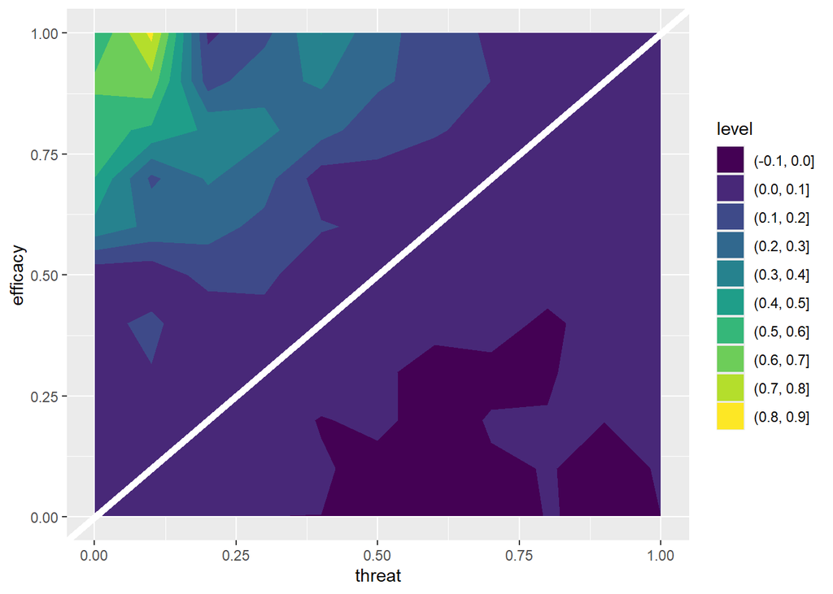

```r
DelPCcontour(0.5)
```

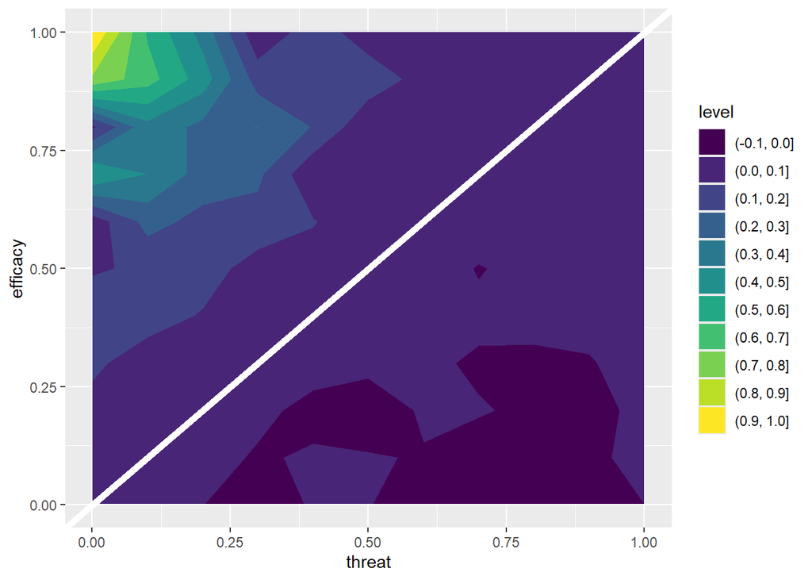

```r
DelPCcontour(0.1)
```

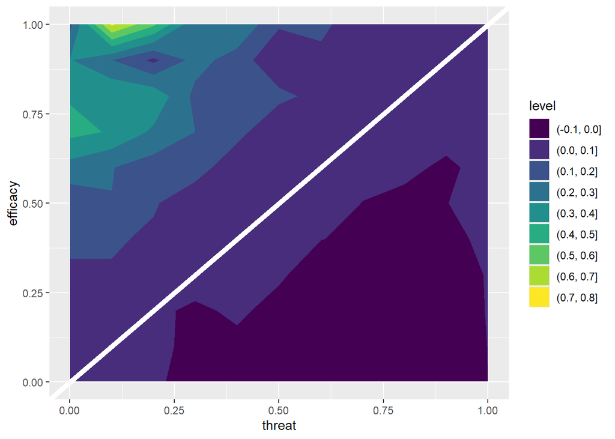

```r
DelPCcontour(0.01)
```

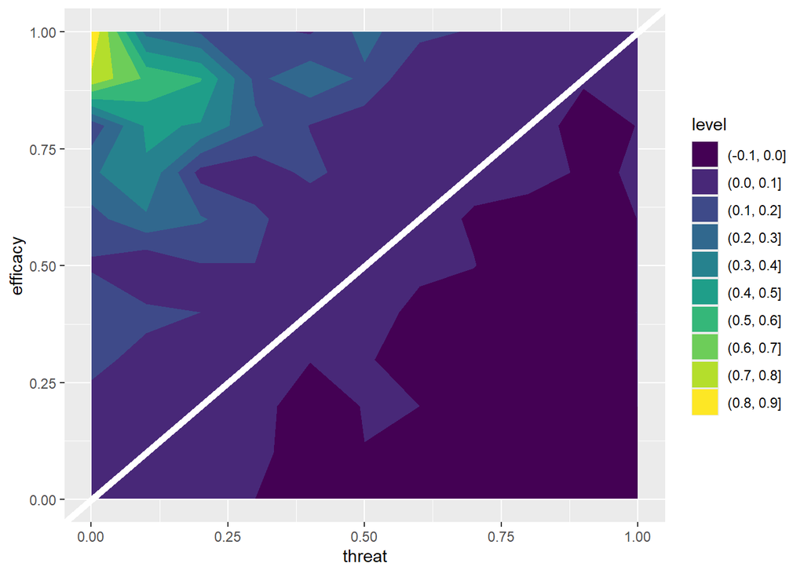

```r
DelPCcontour(0.001)
```

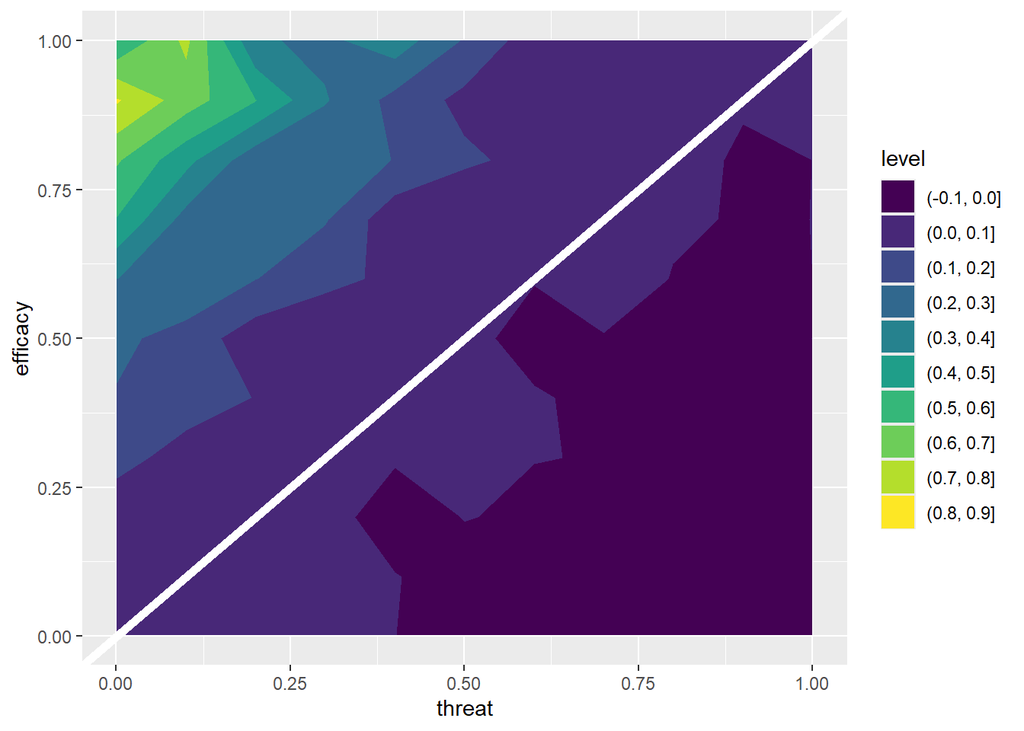

```r
DelPCcontour(0.0001)
```

In all of these plots there is a dark blue region with negative values of $\Delta P_C$. These plots are stochastic but the region is larger at lower prevalence and when threat is high but efficacy is low.

### Building to Prevalence trade off figure

Here we recreate a version of Figure 4 in [Walters et al](https://www.medrxiv.org/content/10.1101/2021.07.16.21260521v1)

```r
prevalence <- 0.1

contactrate <- 50 #(per tray)
probtransmissionpercontact <- 1/15 # beta=gamma, same either direction
transmission <- probtransmissionpercontact*contactrate*prevalence

recov <- 1 # recovery rate
probtraycontaminated <- transmission/(transmission+recov)
trayspercustomer <- 2 # trays per customer
Deltaprev <- (1-prevalence)*trayspercustomer*probtransmissionpercontact*probtraycontaminated

PC00 <- prevalence + Deltaprev
eta <- prevalence/PC00*(1-trayspercustomer*probtransmissionpercontact)

comp <- data.frame(eps=rep(seq(0,1,0.01), 101))
comp$tau <-  sort(comp$eps)
comp$rhoincrease <- comp$tau*comp$eps
comp$rhononincrease <- comp$rhoincrease*(1 - comp$tau+comp$eps)
comp$Phi <- 1-(1-eta)*probtraycontaminated*(1-comp$rhononincrease)/(1-probtraycontaminated*comp$rhononincrease)
comp$critarea <- comp$eps - comp$tau*(1 - comp$tau+comp$eps)*comp$Phi

p1 <- ggplot(data=comp)+
     geom_contour_filled(mapping=aes(y=eps, x=tau, z=rhoincrease))+
  labs(title='Prob. of adherence \nbefore contact', x=TeX('$\\tau$'),y=TeX('$\\epsilon$'))
p2 <- ggplot(data=comp)+
     geom_contour_filled(mapping=aes(y=eps, x=tau, z=rhononincrease))+
  labs(title='Prob. of adherence \nafter contact', x=TeX('$\\tau$'),y=TeX('$\\epsilon$'))
p3 <- ggplot(data=comp)+
     geom_contour_filled(mapping=aes(y=eps, x=tau, z=Phi))+
  labs(title=TeX('$\\Phi$'), x=TeX('$\\tau$'),y=TeX('$\\epsilon$'))
p4 <- ggplot(data=comp)+
     geom_contour_filled(mapping=aes(y=eps, x=tau, z=critarea))+
     geom_abline(intercept=0, slope=1, color='white', lwd=2)+
  labs(title='Critical Region', x=TeX('$\\tau$'),y=TeX('$\\epsilon$'))
```

Now plot results, firstly just plot back the probability of uptake of sansitiser given efficacy and threat.

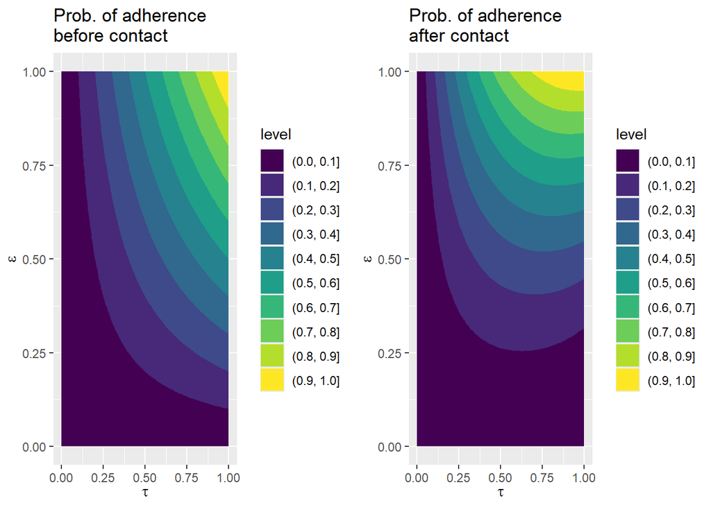

```r
grid.arrange(p1, p2,  ncol=2)
```

The left hand plot shows the probability of hand sanitiser usage before contact and the right hand plot the probability of hand sanitiser after contact (with $k=1$ for purpose of this plot) for the threat and efficacy interaction assumed in paper.

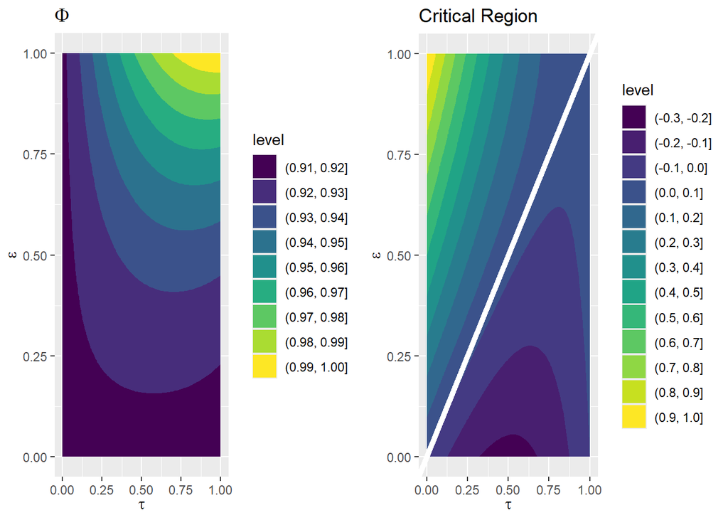

```r
grid.arrange(p3, p4,  ncol=2)
```

Left hand plot shows the value of $\Phi$ from section 3.2 of paper whilst the right hand plot shows result of equation (12). If the right hand plot shows a region with negative values this indicates parameter couplings where only placing sanitiser after is not effective.